# Exploratory analysis climatics data

We make a graphic study of the global temperature evolution from 1850. We want to know:

- If there have been a important increasing of global temperature .
- If it is produced more anomalies than before, thermally.
- To take ideas and descriptors as for the given information.

Data are global temperatures and are described like:

- Date: starts in 1750 for average land temperature and 1850 for max and min land temperatures and global ocean and land temperatures
- LandAverageTemperature: global average land temperature in celsius
- LandAverageTemperatureUncertainty: the 95% confidence interval around the average
- LandMaxTemperature: global average maximum land temperature in celsius
- LandMaxTemperatureUncertainty: the 95% confidence interval around the maximum land temperature
- LandMinTemperature: global average minimum land temperature in celsius
- LandMinTemperatureUncertainty: the 95% confidence interval around the minimum land temperature
- LandAndOceanAverageTemperature: global average land and ocean temperature in celsius
- LandAndOceanAverageTemperatureUncertainty: the 95% confidence interval around the global average land and ocean temperature

### Let’s study the dataset

We load data and show its information:

```r
data <- read.csv("./data/global-temperatures-data.csv")
head(data)
```

|  | dt | LandAverageTemperature | LandAverageTemperatureUncertainty | LandMaxTemperature | LandMaxTemperatureUncertainty | LandMinTemperature | LandMinTemperatureUncertainty | LandAndOceanAverageTemperature | LandAndOceanAverageTemperatureUncertainty |
| --- | --- | --- | --- | --- | --- | --- | --- | --- | --- |
| 1 | 1750-01-01 | 3.034 | 3.574 | NA | NA | NA | NA | NA | NA |
| 2 | 1750-02-01 | 3.083 | 3.702 | NA | NA | NA | NA | NA | NA |
| 3 | 1750-03-01 | 5.626 | 3.076 | NA | NA | NA | NA | NA | NA |
| 4 | 1750-04-01 | 8.490 | 2.451 | NA | NA | NA | NA | NA | NA |
| 5 | 1750-05-01 | 11.573 | 2.072 | NA | NA | NA | NA | NA | NA |
| 6 | 1750-06-01 | 12.937 | 1.724 | NA | NA | NA | NA | NA | NA |

Like we can observe, data contains missing values (`NA`). For this, we are going to remove all rows which contains missing values:

```r
data <- na.omit(data)
head(data)
```

|  | dt | LandAverageTemperature | LandAverageTemperatureUncertainty | LandMaxTemperature | LandMaxTemperatureUncertainty | LandMinTemperature | LandMinTemperatureUncertainty | LandAndOceanAverageTemperature | LandAndOceanAverageTemperatureUncertainty |
| --- | --- | --- | --- | --- | --- | --- | --- | --- | --- |
| 1201 | 1850-01-01 | 0.749 | 1.105 | 8.242 | 1.738 | -3.206 | 2.822 | 12.833 | 0.367 |
| 1202 | 1850-02-01 | 3.071 | 1.275 | 9.970 | 3.007 | -2.291 | 1.623 | 13.588 | 0.414 |
| 1203 | 1850-03-01 | 4.954 | 0.955 | 10.347 | 2.401 | -1.905 | 1.410 | 14.043 | 0.341 |
| 1204 | 1850-04-01 | 7.217 | 0.665 | 12.934 | 1.004 | 1.018 | 1.329 | 14.667 | 0.267 |
| 1205 | 1850-05-01 | 10.004 | 0.617 | 15.655 | 2.406 | 3.811 | 1.347 | 15.507 | 0.249 |
| 1206 | 1850-06-01 | 13.150 | 0.614 | 18.946 | 2.817 | 7.106 | 0.857 | 16.353 | 0.245 |

Let’s see how the columns data are:

```r
str(data)
```

```
'data.frame':   1992 obs. of  9 variables:
 $ dt                                       : Factor w/ 3192 levels "1750-01-01","1750-02-01",..: 1201 1202 1203 1204 1205 1206 1207 1208 1209 1210 ...
 $ LandAverageTemperature                   : num  0.749 3.071 4.954 7.217 10.004 ...
 $ LandAverageTemperatureUncertainty        : num  1.105 1.275 0.955 0.665 0.617 ...
 $ LandMaxTemperature                       : num  8.24 9.97 10.35 12.93 15.65 ...
 $ LandMaxTemperatureUncertainty            : num  1.74 3.01 2.4 1 2.41 ...
 $ LandMinTemperature                       : num  -3.21 -2.29 -1.91 1.02 3.81 ...
 $ LandMinTemperatureUncertainty            : num  2.82 1.62 1.41 1.33 1.35 ...
 $ LandAndOceanAverageTemperature           : num  12.8 13.6 14 14.7 15.5 ...
 $ LandAndOceanAverageTemperatureUncertainty: num  0.367 0.414 0.341 0.267 0.249 0.245 0.238 0.28 0.254 0.297 ...
 - attr(*, "na.action")=Class 'omit'  Named int [1:1200] 1 2 3 4 5 6 7 8 9 10 ...
  .. ..- attr(*, "names")= chr [1:1200] "1" "2" "3" "4" ...
```

The date of data are factor, therefore, we are going to convert this factor to date:

```r
data$dt <- as.Date(data$dt, "%Y-%m-%d")
str(data)
```

```
'data.frame':   1992 obs. of  9 variables:
 $ dt                                       : Date, format: "1850-01-01" "1850-02-01" "1850-03-01" "1850-04-01" ...
 $ LandAverageTemperature                   : num  0.749 3.071 4.954 7.217 10.004 ...
 $ LandAverageTemperatureUncertainty        : num  1.105 1.275 0.955 0.665 0.617 ...
 $ LandMaxTemperature                       : num  8.24 9.97 10.35 12.93 15.65 ...
 $ LandMaxTemperatureUncertainty            : num  1.74 3.01 2.4 1 2.41 ...
 $ LandMinTemperature                       : num  -3.21 -2.29 -1.91 1.02 3.81 ...
 $ LandMinTemperatureUncertainty            : num  2.82 1.62 1.41 1.33 1.35 ...
 $ LandAndOceanAverageTemperature           : num  12.8 13.6 14 14.7 15.5 ...
 $ LandAndOceanAverageTemperatureUncertainty: num  0.367 0.414 0.341 0.267 0.249 0.245 0.238 0.28 0.254 0.297 ...
 - attr(*, "na.action")=Class 'omit'  Named int [1:1200] 1 2 3 4 5 6 7 8 9 10 ...
  .. ..- attr(*, "names")= chr [1:1200] "1" "2" "3" "4" ...
```

Now, we extract the month and year from date and we add it to data:

```r
data$Month <- format(data$dt, "%m")
data$Month.String <- format(data$dt, "%B")
data$Year <- format(data$dt, "%Y")
head(data)
```

|  | dt | LandAverageTemperature | LandAverageTemperatureUncertainty | LandMaxTemperature | LandMaxTemperatureUncertainty | LandMinTemperature | LandMinTemperatureUncertainty | LandAndOceanAverageTemperature | LandAndOceanAverageTemperatureUncertainty | Month | Month.String | Year |
| --- | --- | --- | --- | --- | --- | --- | --- | --- | --- | --- | --- | --- |
| 1201 | 1850-01-01 | 0.749 | 1.105 | 8.242 | 1.738 | -3.206 | 2.822 | 12.833 | 0.367 | 01 | enero | 1850 |
| 1202 | 1850-02-01 | 3.071 | 1.275 | 9.970 | 3.007 | -2.291 | 1.623 | 13.588 | 0.414 | 02 | febrero | 1850 |
| 1203 | 1850-03-01 | 4.954 | 0.955 | 10.347 | 2.401 | -1.905 | 1.410 | 14.043 | 0.341 | 03 | marzo | 1850 |
| 1204 | 1850-04-01 | 7.217 | 0.665 | 12.934 | 1.004 | 1.018 | 1.329 | 14.667 | 0.267 | 04 | abril | 1850 |
| 1205 | 1850-05-01 | 10.004 | 0.617 | 15.655 | 2.406 | 3.811 | 1.347 | 15.507 | 0.249 | 05 | mayo | 1850 |
| 1206 | 1850-06-01 | 13.150 | 0.614 | 18.946 | 2.817 | 7.106 | 0.857 | 16.353 | 0.245 | 06 | junio | 1850 |

### Let’s represent the average temperatures by month from 1850

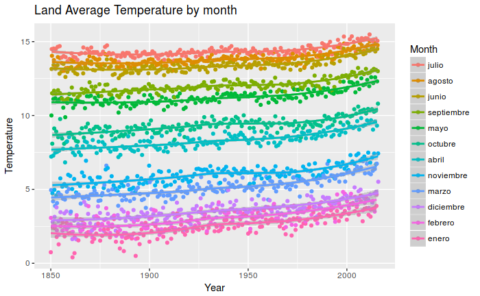

```r
# Load the necessary libraries:
library(ggplot2)
library(dplyr)
# Represent the average temperatures
ggplot(data, aes(x = dt, y = LandAverageTemperature, colour = reorder(Month.String, -LandAverageTemperature, mean))) +
  geom_point() +
  geom_smooth(method = "loess") +
  labs(title = "Land Average Temperature by month", x = "Year", y = "Temperature", colour = "Month")
```

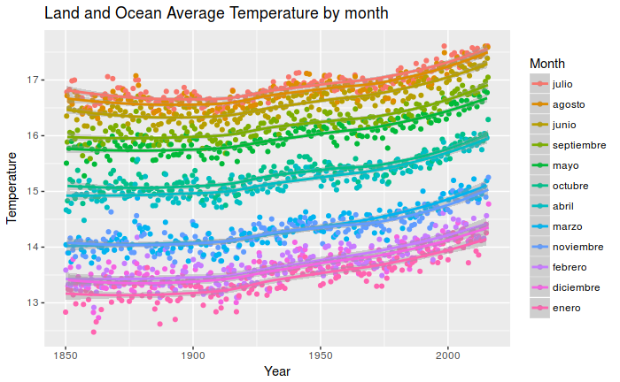

```r
ggplot(data, aes(x = dt, y = LandAndOceanAverageTemperature, colour = reorder(Month.String, -LandAndOceanAverageTemperature, mean))) +
  geom_point() +
  geom_smooth(method = "loess") +
  labs(title = "Land and Ocean Average Temperature by month", x = "Year", y = "Temperature", colour = "Month")
```

### Let’s represent the differences between the land maximum and minimum temperatures

First, we are going to the maximum and minimum temperatures evolution over time:

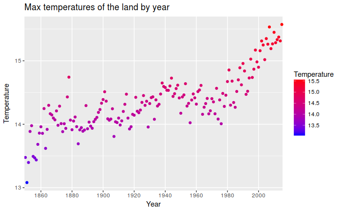

```r
# Let's represent the mean of maximum temperatures by year
max_by_year <- data %>%
                filter(Year >= 1850) %>%
                group_by(Year) %>%
                summarize(Temperature = mean(LandMaxTemperature))
ggplot(max_by_year, aes(x = Year, y = Temperature, colour = Temperature)) +
  geom_point() +
  geom_smooth(method = "loess") +
  ggtitle("Max temperatures of the land by year") +
  scale_colour_gradient(low = "blue", high = "red") +
  scale_x_discrete(breaks = scales::pretty_breaks(n = 10))
```

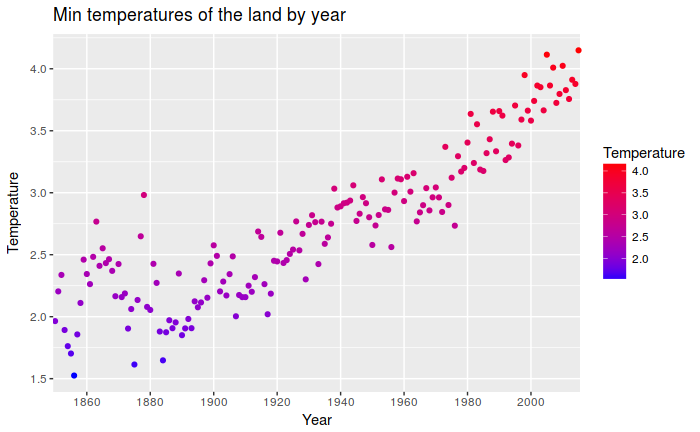

```r
# Let's represent the mean of minimum temperatures by year
min_by_year <- data %>%
                filter(Year >= 1850) %>%
                group_by(Year) %>%
                summarize(Temperature = mean(LandMinTemperature))
ggplot(min_by_year, aes(x = Year, y = Temperature, colour = Temperature)) +
  geom_point() +
  geom_smooth(method = "loess") +
  ggtitle("Min temperatures of the land by year") +
  scale_colour_gradient(low = "blue", high = "red") +
  scale_x_discrete(breaks = scales::pretty_breaks(n = 10))
```

Now, we are going to observe the difference between maximum and minimum temperatures:

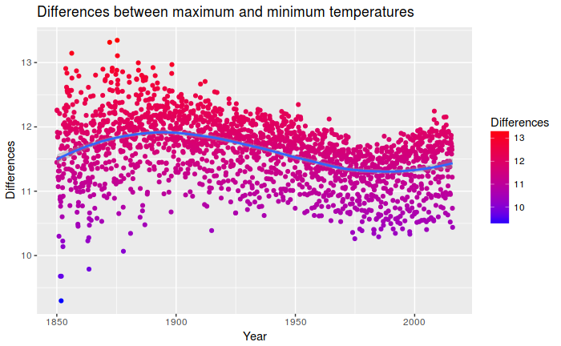

```r
# We add a new column with differences between maximum and minimum temperatures:
data$MaxMinLandDifferences <- data$LandMaxTemperature - data$LandMinTemperature
ggplot(data, aes(x = dt, y = MaxMinLandDifferences, colour = MaxMinLandDifferences)) +
  geom_point() +
  geom_smooth(method = "loess") +
  scale_color_gradient(low = "blue", high = "red") +
  labs(title = "Differences between maximum and minimum temperatures",
       x = "Year",
       y = "Differences",
       colour = "Differences")
```

Also, we are going to observe this difference by quarter evolution:

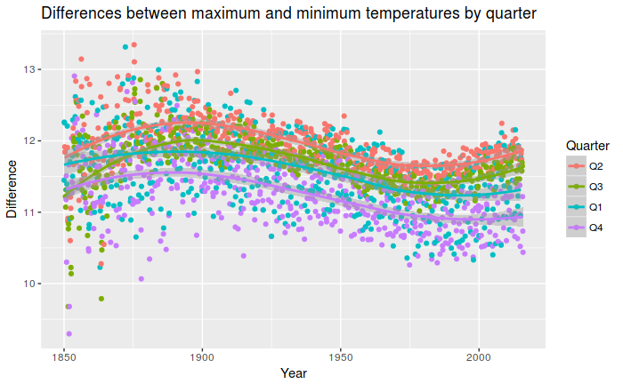

```r
# We add a new colum with quarter of year:
data$Quarter <- quarters(data$dt)
# We represent the difference by quarter:
ggplot(data, aes(x = dt, y = MaxMinLandDifferences, color = reorder(Quarter, -MaxMinLandDifferences, mean))) +
  geom_point() +
  geom_smooth(method = "loess") +
  labs(title = "Differences between maximum and minimum temperatures by quarter",
       x = "Year",
       y = "Difference",
       colour = "Quarter")
```

### Let’s see the evolution of uncertainty above the land and the ocean temperatures

```r
head(data)
```

|  | dt | LandAverageTemperature | LandAverageTemperatureUncertainty | LandMaxTemperature | LandMaxTemperatureUncertainty | LandMinTemperature | LandMinTemperatureUncertainty | LandAndOceanAverageTemperature | LandAndOceanAverageTemperatureUncertainty | Month | Month.String | Year | MaxMinLandDifferences | Quarter |
| --- | --- | --- | --- | --- | --- | --- | --- | --- | --- | --- | --- | --- | --- | --- |
| 1201 | 1850-01-01 | 0.749 | 1.105 | 8.242 | 1.738 | -3.206 | 2.822 | 12.833 | 0.367 | 01 | enero | 1850 | 11.448 | Q1 |
| 1202 | 1850-02-01 | 3.071 | 1.275 | 9.970 | 3.007 | -2.291 | 1.623 | 13.588 | 0.414 | 02 | febrero | 1850 | 12.261 | Q1 |
| 1203 | 1850-03-01 | 4.954 | 0.955 | 10.347 | 2.401 | -1.905 | 1.410 | 14.043 | 0.341 | 03 | marzo | 1850 | 12.252 | Q1 |
| 1204 | 1850-04-01 | 7.217 | 0.665 | 12.934 | 1.004 | 1.018 | 1.329 | 14.667 | 0.267 | 04 | abril | 1850 | 11.916 | Q2 |
| 1205 | 1850-05-01 | 10.004 | 0.617 | 15.655 | 2.406 | 3.811 | 1.347 | 15.507 | 0.249 | 05 | mayo | 1850 | 11.844 | Q2 |
| 1206 | 1850-06-01 | 13.150 | 0.614 | 18.946 | 2.817 | 7.106 | 0.857 | 16.353 | 0.245 | 06 | junio | 1850 | 11.840 | Q2 |

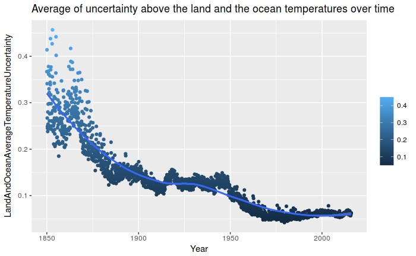

```r
ggplot(data, aes(x = dt, y = LandAndOceanAverageTemperatureUncertainty, colour = LandAndOceanAverageTemperatureUncertainty)) +
  geom_point() +
  geom_smooth(method = "loess") +
  scale_color_gradient() +
  labs(title = "Average of uncertainty above the land and the ocean temperatures over time",
       x = "Year",
       color = "")
```

With this, we can observe how the uncertainty of temperatures has been decreasing over time. This means that the measurements have improve a lot.

### Let’s see the land and the ocean temperature distribution throught the year

We are going to represent data with boxplot chart:

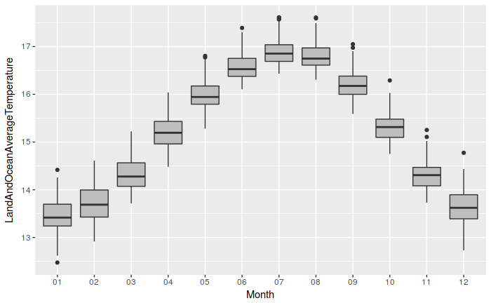

```r
ggplot(data, aes(x = Month, y = LandAndOceanAverageTemperature)) +
  geom_boxplot(fill = "gray")
```

Now, we are going to represent the temperatures distribution by month throught the selected years:

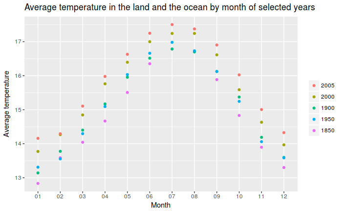

```r
selected_years <- data[data$Year %in% c(1850, 1900, 1950, 2000, 2005), ]
ggplot(selected_years, aes(x = Month, y = LandAndOceanAverageTemperature, colour = reorder(Year, -LandAndOceanAverageTemperature, mean))) +
  geom_point() +
  scale_color_discrete("") +
  labs(title = "Average temperature in the land and the ocean by month of selected years",
       x = "Month",
       y = "Average temperature")
```